# Oral Health and Diabetes

DocOfi  
April 27, 2016

Coordinator  
Project Oral Health for Juvenile Diabetics

### Diabetes and Oral Health share certain Commonalities

- Sugar intake largely determines disease in oral health and diabetes.
- Success in improving oral health and blood sugar levels are largely dependent on the patient's knowledge and motivation.
- Both require considerable amount of money. Diabetes requires frequent monitoring of blood sugar levels, daily injections of insulin while dental treatment is not subsidize by the medical insurance.
- Increasing awareness and educating the patient has been shown to be highly effective in improving oral health and diabetes

### DMFT index among Type 1 Diabetics

The DMFT index is a simple count of the number of decayed, missing and filled teeth in an individual averaged over a population or age group. It is the a widely accepted method for comparing prevalence of tooth decay between populations

```
  AgeGrp Decayed Missing Filled DMFT
1    1-5     1.0     0.0    2.5  3.5
2   6-10     6.9     0.5    0.8  8.2
3  11-15     6.6     0.8    1.3  8.7
4  16-20    11.4     1.0    1.7 14.3
5  21-25     8.9     3.5    1.4 14.3
6  26-30     5.4     7.5    4.3 19.3
```

### Decayed and Missing teeth per age group

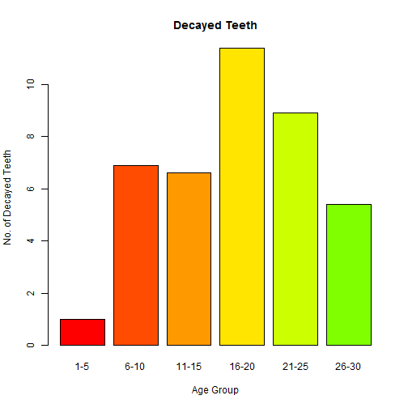

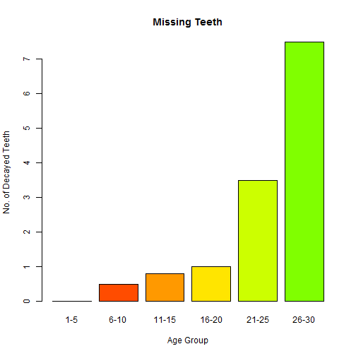

### FIlled teeth and total DMFT per age group

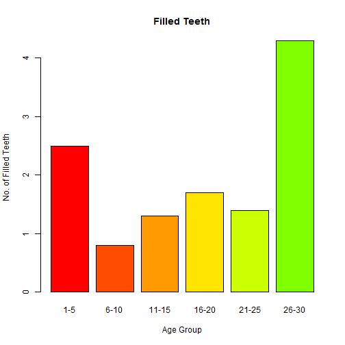

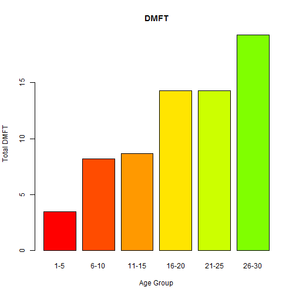

### Oral Health = Systemic Health

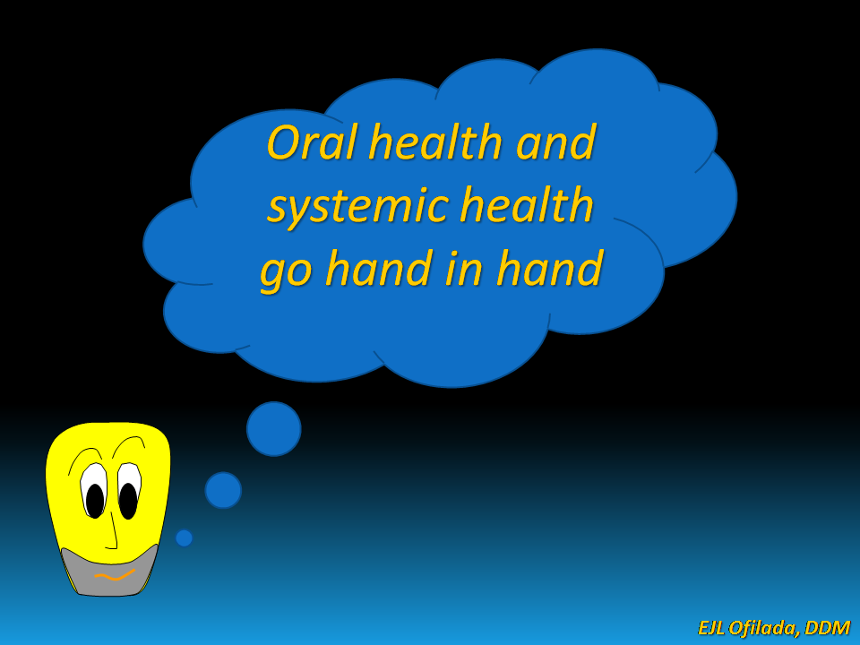

A common risk factor approach to improving oral and systemic health among patients with diabetes may offer a better solution.

### References and Links

[A Survey on the Barriers to Dental Care among Individuals with Type 1 Diabetes](http://74.81.82.220/index.php/pjim/436-phil-journal-of-internal-medicine-vol51-no2)

[figure not shown]

Project Oral Health for juvenile Diabetics

[Oral Health Status of Children Attending a Summer Camp for Diabetes Children](http://asean-endocrinejournal.org/index.php/JAFES/article/view/231/657)

[Diabetes and Oral Heath](http://www.slideshare.net/pinoydental/dental-comics-by-dr-ed-ofilada)